# Building employment network structures for Northeast States in the US

Results & repro guide

##### Sample network outputs:

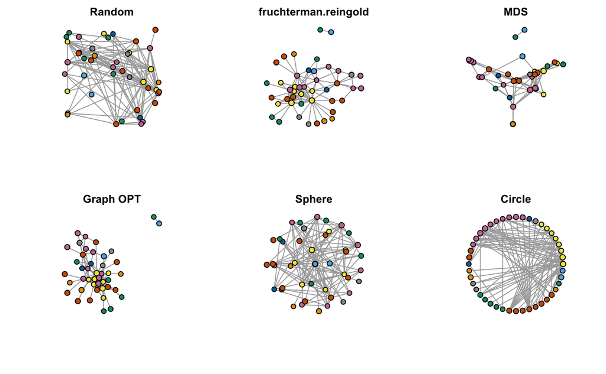

##### Column mapping:

**id:** The id number of the observation.

**to:** The node number that the link is in the direction of.

**from:** The node number that the link is directed from.

**industry_id1:** The industry ID for the “to” node. Can be used as an attribute for labelling or coloring.

**industry_id1:** The industry ID for the “from” node. Can be used as an attribute for labelling or coloring.

**industry1:** The industry name for the “to” node. Can be used as an attribute for labelling or coloring.

**industry2:** The industry name for the “from” node. Can be used as an attribute for labelling or coloring.

**value:** A calculated field indicating the number of interactions between the two industries. Can be used for coloring, fill, size, etc.

##### Creating the Network DF

If you’re reading your data in from a CSV, excel etc. use the following to create a simple dataframe that contains the coluimns as needed. The below pulls columns from a file called ny_network_data. Replace “ny_network_data” for whatever your filename is. $ indicates a call to the columns within that file structure, you can edit this to meet your own column names.

R code to create dataframe:

```r
simple_network <- data.frame(
  to=ny_network_data$from,
  from=ny_network_data$to,
  id = ny_network_data$id,
  to_industry = ny_network_data$industry2,
  from_industry = ny_network_data$industry1,
  value = ny_network_data$value,
  title = as.character(ny_network_data$industry2)
)
```

##### Formatting the dataframe into a network graph.

The igraph library provides multiple functions that convert dataframes and other data structures into a format that can be read by multiple plotting functions within R. Below is an example showing how to run your df through the graph_from_data_frame function.

```r
edge_network <- graph_from_data_frame(d=simple_network, directed=F)
```

##### Plotting

Once your data is structured in a way that graphing functions can read it, you’re ready to plot. There are multiple tools and libraries that can be used to plot networks, each of them has their benefits and limitations.

The below represents the most basic (and built-in), but powerful use of “plot.”

```r
plot(edge_network)
```

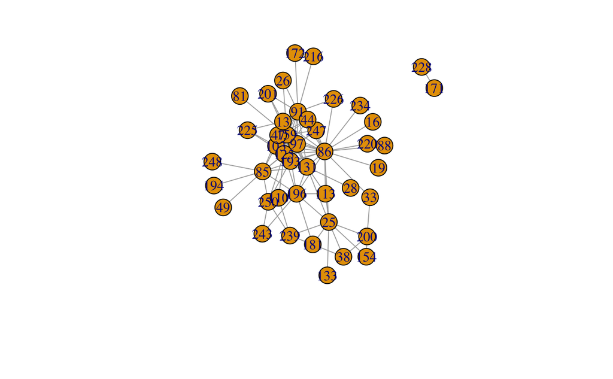

The hard work is done, the rest is just formatting and structuring of the network diagram to make it more easily readable and valuable to a viewer. Using the extra columns in your df, you can start to play with sizes of the notes, length of edges, colors, as well as labels and titles.

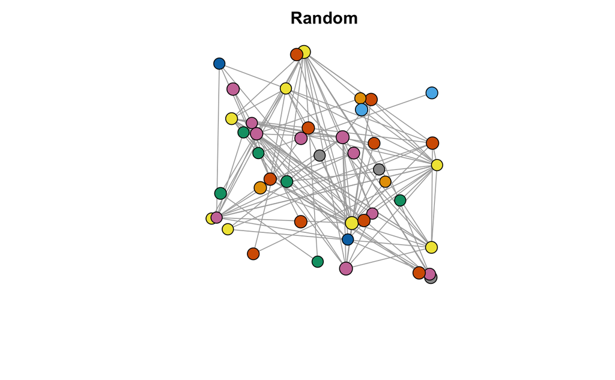

```r
plot(edge_network,
     vertex.size=simple_network$value*.5,           # Mapping the size of the nodes to value.
     vertex.color=simple_network$from_industry,     # Mapping the color of the nodes to industries
     vertex.label=" ",                              # Placeholder before figuring out how to hover.
     layout=layout.random, main="Random")           # Playing with layouts (random, sphere, etc.)
```

##### To update with more guidance soon!